# abyssEdge: Tsallis entropy workflow

abyssEdge developers

2026-01-30

## Overview

This vignette demonstrates how to compute and apply Tsallis entropy to transcript-level expression data using `abyssEdge`. It focuses on three practical goals: (1) compute per-sample, per-gene diversity measures across a range of sensitivity parameters `q`; (2) compare those measures between sample groups; and (3) visualize and inspect transcript-level patterns that explain differences.

### Motivation

- Many genes express multiple isoforms whose relative abundances can be multimodal or heavy-tailed. Standard mean-based comparisons may miss changes in isoform dominance or heterogeneity.
- Tsallis entropy provides a tunable way to weight rare versus dominant isoforms by varying `q`, producing a “q-curve” that reveals scale-dependent diversity differences.

### High-level workflow

1. Preprocess counts and filter low-abundance transcripts.
2. Compute relative transcript proportions within each gene and evaluate Tsallis entropy across one or more `q` values.
3. Summarize per-gene values across samples (mean/median) and test for differences between groups (Wilcoxon or permutations).
4. Visualize q-curves and inspect transcript-level counts for top genes.

### Key package features

- `calculate_diversity()` — compute Tsallis (and other) diversity measures.
- `calculate_difference()` — summarize per-gene diversity across samples and run pairwise tests (mean/median + Wilcoxon or label-shuffle).
- `calculate_lm_interaction()` — test for condition-by-q interactions across a sequence of `q` values.
- Plotting helpers: `plot_tsallis_q_curve()`, `plot_tsallis_violin_multq()`, `plot_tsallis_density_multq()`, `plot_ma()`, `plot_volcano()`, and `plot_top_transcripts()` for diagnostics and inspection.

## What is Tsallis entropy?

Tsallis entropy is a one-parameter family of diversity measures that generalizes Shannon entropy via a parameter `q` which tunes sensitivity to rare vs dominant categories. For a discrete probability vector $p=(p_1,\dots,p_n)$,

$$S_q(p) = \frac{1-\sum_{i=1}^n p_i^q}{q-1},$$

where different values of `q` emphasize different abundance scales: `q<1` increases sensitivity to rare categories while `q>1` highlights dominant modes. The rest of this document explains the mathematical limits and practical considerations in more detail.

The formula above interpolates between several classical diversity indices; the following limiting identities and formulas are useful for interpretation and for constructing normalized scores.

### Limiting cases and useful identities

This section expands the most useful closed-form identities and explains their interpretation for transcript-level data.

- Limiting case ($q\to 1$) — Shannon entropy (derivation and meaning):

  Let $f(q)=\sum_i p_i^q=\sum_i e^{q\log p_i}$. A first-order Taylor expansion about $q=1$ gives

  $$p_i^q\approx p_i+(q-1)p_i\log p_i + O((q-1)^2).$$

  Summing and rearranging yields

  $$1-\sum_i p_i^q \approx -(q-1)\sum_i p_i\log p_i,$$

  so

  $$\lim_{q\to 1} S_q(p) = -\sum_{i=1}^n p_i\log p_i,$$

  the Shannon entropy. In transcriptomics Shannon measures uncertainty in isoform choice: higher Shannon indicates more even isoform usage; lower Shannon reflects dominance by one/few isoforms. Compute Shannon directly at `q=1` or use the analytic limit when `q` is near 1 for numerical stability.
- $q=0$ (richness-like):

  Because $p_i^0=1$ for $p_i>0$,

  $$S_0 = \frac{1-\sum_i 1}{0-1} = W-1,$$

  where $W$ is the number of expressed (non-zero) isoforms. Thus $S_0$ is essentially a richness measure and is highly sensitive to sequencing depth, dropouts and filtering thresholds; treat $q=0$ results cautiously.
- $q=2$ (Gini–Simpson / collision index):

  $$S_2 = 1 - \sum_{i=1}^n p_i^2,$$

  the probability that two independent draws produce different isoforms. `S_2` emphasizes dominant isoforms and is less sensitive to rare isoforms and low-count noise than small `q` values.
- Maximum attainable $S_q$ and normalization:

  For a gene with $m$ expressed isoforms the uniform distribution $p_i=1/m$ attains

  $$S_{q,\max}(m)=\frac{1-m^{1-q}}{q-1}.$$

  Define a normalized score

  $$\tilde S_q = \frac{S_q}{S_{q,\max}(m)}\in[0,1],$$

  to compare genes with different observed isoform counts; use the number of reliably observed isoforms (post-filtering) for $m$ rather than the raw annotated isoform count.

Practical implications for transcriptomics

- Interpretation across `q`: small `q` values (e.g., `q\ll 1`) amplify low-abundance isoforms and are therefore sensitive to rare-isoform biology but also to technical noise; large `q` values (`q>1`) emphasize the dominant isoforms and are robust to sparse counts.
- Data used to form proportions `p_i`: because fragment counts are proportional to transcript abundance times transcript length, compute within-gene proportions using length-corrected estimates (TPM or effective-length adjusted counts from Salmon/kallisto) or use UMI counts (not length-biased). Using raw unadjusted counts can bias `p_i` and therefore `S_q`.
- Handling zeros and pseudocounts: zeros are common (dropouts, low depth). For `q<1` small probabilities are amplified, so add a documented small pseudocount (e.g., 1 read or a small fraction) or filter transcripts never observed. Report filtering and pseudocount choices.
- Finite-sample bias and uncertainty: diversity estimates have finite-sample bias (particularly for `q<1`); use bootstrap, permutation, or replicate-aware models to quantify uncertainty.

These identities are mathematically correct under the usual probability constraints and the practical caveats above summarize how sequencing and quantification choices interact with limiting cases when applying Tsallis entropy to gene-expression data.

#### Additional theoretical remarks (for careful users)

- Concavity and ordering: for `q>0` Tsallis entropy is commonly stated to be concave (see Tsallis 2009); this aids reasoning about mixture distributions. Specific convexity/concavity results can depend on the parameter regime and support of `p`, so verify the required inequalities for the `q` range used in an analysis.
- Monotone transforms and ranking: because Rényi and Tsallis entropies are related by a monotone transformation (for fixed $q$ with valid domain), they induce the same ordering of distributions. Thus, for ranking genes by diversity at a fixed $q$ either measure may be used, but the numeric differences and variance properties differ.
- Compositional and closure effects: transcript-level proportions are compositional (they sum to one within each gene). This implies that changes in one isoform necessarily affect others; interpret entropy shifts with this coupling in mind. For modeling or hypothesis testing, Dirichlet-multinomial or hierarchical compositional models can be used to separate technical sampling effects from biological variation.
- Practical estimators and bias correction: several bias-correction approaches exist for diversity indices (e.g., coverage-adjusted or Chao-type estimators for richness/Hill numbers). For Shannon and for Hill numbers there are established bootstrap and jackknife corrections; for `S_q` similar bootstrap-based bias estimation works well in practice when sample sizes are moderate. Where possible, use resampling to obtain confidence intervals for q-curve features (slopes, differences).
- Using escort distributions in downstream models: escort distributions reweight probabilities and are useful when defining $q$-expectation constraints or when modeling averages that emphasize specific abundance scales. For inference, escort-based reweighting can be used to build tests that are explicitly sensitive to rare or dominant isoforms.
- Hill numbers (effective number of categories): it is often useful to convert entropies to Hill numbers (diversity numbers) defined by

  $$D_q(p) = \Big(\sum_{i=1}^n p_i^q\Big)^{1/(1-q)} \quad (q\neq 1),$$

  with the Shannon-case limit $D_1(p)=\exp\big(-\sum_i p_i\log p_i\big)$. Using $\sum_i p_i^q = 1-(q-1)S_q(p)$ one obtains the mapping

  $$D_q(p)=\big(1-(q-1)S_q(p)\big)^{1/(1-q)},$$

  which provides an intuitive “effective number of isoforms” interpretation and can help comparing diversity across genes.

These remarks refine the theoretical picture and should help bridge the mathematical properties of `S_q` with practical modeling choices in transcriptomics.

### Relation to Rényi entropy

Rényi entropy is another one-parameter family defined by
$$R_q(p) = \frac{1}{1-q}\log\Big(\sum_{i=1}^n p_i^q\Big).$$
Because $\sum_i p_i^q = 1 - (q-1)S_q(p)$ the two definitions are related by
$$R_q(p)=\frac{1}{1-q}\log\big(1-(q-1)S_q(p)\big).$$
This mapping is strictly monotonic for fixed $q\neq 1$ (when the log’s argument is positive), so `S_q` and `R_q` induce the same ranking of distributions; they are interchangeable for exploratory ranking after an appropriate monotone transform.

### Nonextensivity (pseudo-additivity)

For independent systems $A$ and $B$ Tsallis entropy satisfies
$$S_q(A\cup B)=S_q(A)+S_q(B)+(1-q)S_q(A)S_q(B),$$
which reduces to ordinary additivity when `q=1`.

### Tsallis entropy for complex systems and the edge of chaos

Tsallis entropy has been used where Boltzmann–Gibbs assumptions are violated (long-range correlations, multifractals, near-critical dynamics). The parameter `q` modulates sensitivity to rare events or heavy tails: `q<1` amplifies low-abundance categories while `q>1` emphasises dominant modes. Researchers use q-curves to probe scale-dependent structure and occasionally to investigate regimes described as the “edge of chaos”, but such claims require careful experimental design, replication, and independent validation.

## Practical notes and tips

- Domain and zeros: compute Tsallis for `q>0` in sparse transcript data. For `q\le 0` the term $p_i^q$ may diverge at $p_i=0`. Remedies: (i) filter transcripts with consistently zero counts across samples, or (ii) add a documented small pseudocount before computing proportions.
- Choosing `q`: select a small grid (e.g., `q in {0.1,0.2,0.5,1,1.5,2}`) that spans tail-sensitive and dominant-mode-sensitive regimes and visualize a q-curve rather than relying on a single `q` value.
- Normalization across genes: normalize by the maximum attainable $S_q$ for the gene’s isoform count to obtain a bounded score for cross-gene comparisons.
- Numerical stability near `q=1`: compute Shannon entropy directly at `q=1` or use the analytic first-order limit to avoid cancellation errors.
- Interpretation with tests: the Wilcoxon rank-sum test used in `calculate_difference()` compares rank distributions and therefore aligns naturally with median summaries. Recommended practices:
  - Use `method = "median"` when pairing the Wilcoxon test with an effect-size summary, or compute and report both mean and median when `method = "mean"` is used for reporting.
  - When using paired tests (`paired = TRUE`), ensure sample ordering and the `samples` vector correctly align so pairs are matched.
- Visualization and reporting: always show q-curves for top genes, report pseudocount and normalization choices, and include sample sizes per group.
  - Permutation recommendation: when using label shuffling (`test = "shuffle"`) set `randomizations` to at least 1000 (preferably 1000–5000) for stable empirical p-value estimates; increase further if you expect very small p-values or perform many tests.

### Recommended experimental designs and use cases for transcriptomics

- Time-series and longitudinal sampling following perturbations to reveal dynamics in q-curves.
- Perturbation gradients (dose–response) to capture transitions in scale- dependent responses.
- Single-cell RNA-seq (UMI-based) and spatial transcriptomics to expose heterogeneity and spatial correlations; ensure sufficient depth for isoform inference and aggregate or model cell-level q-dependence.
- Paired / matched designs and adequate biological replication to increase power and control variability.

### Key technical recommendations

- Use accurate transcript quantifiers (Salmon/kallisto) and sufficient sequencing depth.
- Filter transcripts never observed across samples or add a documented pseudocount before forming proportions.
- Correct for confounders and batch effects prior to q-curve analysis or include them in downstream models.
- Test across `q` on a grid and consider interaction tests (e.g., `calculate_lm_interaction()`) to detect shape differences in q-curves.

The remainder of this vignette shows a minimal analysis workflow using the package helpers: computing per-sample Tsallis values, running simple differential comparisons, and visualizing top genes’ transcript-level patterns.

## Example dataset

An example dataset is included for demonstration. Load the package and data:

```r
# Load packages
suppressPackageStartupMessages({
  library(abyssEdge)
  library(ggplot2)
  library(SummarizedExperiment)
})

# Load required files
coldata_tsv <- system.file("extdata", "coldata.tsv", package = "abyssEdge")
tx2gene_tsv <- system.file("extdata","tx2gene.tsv", package = "abyssEdge")

# Load dataset
data(tcga_brca_luma_dataset)



# Extract gene names and read count data (do not reference ts_se yet)
genes <- tcga_brca_luma_dataset[, 1]
readcounts <- tcga_brca_luma_dataset[, -1]

# If a tx2gene mapping is available and matches the `genes` column, assign
# transcript IDs as rownames of `readcounts` so downstream transcript-level
# plotting functions can use them.
if (nzchar(tx2gene_tsv) && file.exists(tx2gene_tsv)) {
  txmap <- utils::read.delim(tx2gene_tsv, header = TRUE, stringsAsFactors = FALSE)
  if (nrow(txmap) == nrow(readcounts) && all(as.character(txmap$Gen) == as.character(genes))) {
    rownames(readcounts) <- as.character(txmap$Transcript)
  }
}

# Check gene names
head(genes)
```

```
#> [1] "MXRA8"   "MXRA8"   "MXRA8"   "MXRA8"   "MXRA8"   "C1orf86"
```

```r
# Check read count dataset
dim(readcounts)
```

```
#> [1] 1100   40
```

```r
head(readcounts[, 1:5])
```

```
#>           TCGA-A7-A0CH_N TCGA-A7-A0CH_T TCGA-A7-A0D9_N TCGA-A7-A0D9_T
#> MXRA8.1          2858.04         743.56         812.59           0.00
#> MXRA8.2           127.82          21.28          50.87          38.21
#> MXRA8.3           370.22          94.38         368.76          98.12
#> MXRA8.4          7472.00        3564.87        7647.76        3236.28
#> MXRA8.5            25.44          16.91           4.07           7.55
#> C1orf86.1           0.00           0.00           0.00           0.00
#>           TCGA-A7-A0DB_T
#> MXRA8.1          1508.90
#> MXRA8.2            30.10
#> MXRA8.3           167.89
#> MXRA8.4          6360.80
#> MXRA8.5            34.74
#> C1orf86.1           0.00
```

Read optional sample metadata from `coldata.tsv` and preview it if present.

```r
# Read external coldata if available and show a preview
coldata_df <- NULL
if (nzchar(coldata_tsv) && file.exists(coldata_tsv)) {
  coldata_df <- read.table(coldata_tsv, header = TRUE, sep = "\t", stringsAsFactors = FALSE)
  head(coldata_df)
} else {
  message("No external coldata.tsv found via system.file()")
}
```

```
#>           Sample Condition
#> 1 TCGA-A7-A0CH_N    Normal
#> 2 TCGA-A7-A0CH_T     Tumor
#> 3 TCGA-A7-A0D9_N    Normal
#> 4 TCGA-A7-A0D9_T     Tumor
#> 5 TCGA-A7-A0DB_T     Tumor
#> 6 TCGA-A7-A0DB_N    Normal
```

### Data filtering and preprocessing

As a first step, before doing the diversity calculation, you might want to filter out genes with a low overall expression or limit the analysis to transcripts with a sufficient minimum expression level. Expression estimates of transcript isoforms with zero or low expression might be highly variable. For more details on the effect of transcript isoform prefiltering on differential transcript usage, see [this paper](https://doi.org/10.1186/s13059-015-0862-3).

Filter transcripts with fewer than 5 reads in more than 5 samples and update the `genes` vector accordingly.

```r
tokeep <- rowSums(readcounts > 5) > 5

readcounts <- readcounts[tokeep, ]
genes      <- genes[tokeep]
```

We filter lowly-expressed transcripts to reduce noise and improve the stability of diversity estimates.

If you prefer to add a small pseudocount instead of filtering transcripts, do so explicitly and document the choice. Example:

```r
# Option A: add a small integer pseudocount (document this choice)
readcounts_pc <- readcounts + 1L

# Option B: keep original counts but filter lowly-observed transcripts (recommended)
# readcounts <- readcounts[rowSums(readcounts > 5) > 5, ]
```

# Compute normalized Tsallis entropy for a single `q` value.

```r
# compute Tsallis entropy for q = 0.1
q <- 0.1
ts_se <- calculate_diversity(readcounts, genes, method = "tsallis", q = q, norm = TRUE)
head(assay(ts_se)[1:5,1:5])
```

```
#>         TCGA-A7-A0CH_N TCGA-A7-A0CH_T TCGA-A7-A0D9_N TCGA-A7-A0D9_T
#> MXRA8        0.8616275      0.6609111      0.8156972      0.6633580
#> C1orf86      0.0000000      0.0000000      0.0000000      0.0000000
#> PDPN         0.3486679      0.3395884      0.0000000      0.3481643
#> ALDH4A1      0.8111864      0.4667361      0.8621495      0.5069312
#> HNRNPR       0.5204909      0.6683829      0.7395887      0.6537834
#>         TCGA-A7-A0DB_T
#> MXRA8        0.8036333
#> C1orf86      0.0000000
#> PDPN         0.3467400
#> ALDH4A1      0.5046596
#> HNRNPR       0.8287792
```

Map sample metadata (if available) into the `SummarizedExperiment` so plotting functions can use `sample_type` for grouping.

```r
# If we read an external coldata table, map its Condition values to the
# SummarizedExperiment so plotting and downstream functions can use it.
if (!is.null(coldata_df)) {
  sample_base_names <- sub("_q=.*", "", colnames(SummarizedExperiment::assay(ts_se)))
  st_map <- setNames(coldata_df$Condition, coldata_df$Sample)
  sample_types <- unname(st_map[sample_base_names])
  missing_idx <- which(is.na(sample_types))
  if (length(missing_idx) > 0) {
    sample_types[missing_idx] <- infer_sample_group(sample_base_names[missing_idx])
  }
  SummarizedExperiment::colData(ts_se)$sample_type <- sample_types
}
```

# Differential analysis (per-gene means + Wilcoxon)

Convert the `SummarizedExperiment` result to a data.frame expected by `calculate_difference()` and run a simple comparison between sample types.

Before running differential tests we summarize per-gene diversity values across samples and explicitly define sample groups. The example below performs a pairwise comparison between two conditions (e.g., `Normal` vs `Tumor`) using a non-parametric Wilcoxon test on the per-gene diversity summaries. Adjust the `control` and `test` parameters in `calculate_difference()` to suit your experimental design.

```r
# create a sample grouping vector inferred from sample names
# account for per-q column names like 'Sample_q=0.01' by stripping the '_q=...' suffix
sample_base_names <- sub("_q=.*", "", colnames(assay(ts_se)))
if (exists("coldata_df") && !is.null(coldata_df) && "sample_type" %in% colnames(SummarizedExperiment::colData(ts_se))) {
  samples <- as.character(SummarizedExperiment::colData(ts_se)$sample_type)
} else {
  samples <- ifelse(grepl("_N$", sample_base_names), "Normal", "Tumor")
}

# prepare diversity table as data.frame with gene names in first column
div_df <- as.data.frame(assay(ts_se))
div_df <- cbind(genes = rowData(ts_se)$genes, div_df)

# run difference analysis (mean + wilcoxon)
# run difference analysis (mean + paired wilcoxon)
# samples in the example dataset are matched pairs (Normal/Tumor), so use a paired test
res <- calculate_difference(div_df, samples, control = "Normal", method = "mean", test = "wilcoxon", paired = TRUE)
# sort results by adjusted p-value
if ("adjusted_p_values" %in% colnames(res)) {
  res <- res[order(res$adjusted_p_values), , drop = FALSE]
}
head(res)
```

```
#>             genes Tumor_mean Normal_mean mean_difference log2_fold_change
#> C1orf213 C1orf213  0.3783117   0.9639752     -0.58566342      -1.34942042
#> S1PR1       S1PR1  0.9836170   0.9976878     -0.01407073      -0.02049165
#> MBD2         MBD2  0.5199277   0.1655574      0.35437027       1.65097918
#> OSR1         OSR1  0.7722536   0.5440455      0.22820806       0.50534727
#> GFPT1       GFPT1  0.1156779   0.4675860     -0.35190810      -2.01511871
#> KIF9         KIF9  0.5729707   0.3685433      0.20442740       0.63662729
#>          raw_p_values adjusted_p_values
#> C1orf213 0.0002357454         0.0269389
#> S1PR1    0.0007285418         0.0269389
#> MBD2     0.0006535852         0.0269389
#> OSR1     0.0005801974         0.0269389
#> GFPT1    0.0008919014         0.0269389
#> KIF9     0.0006356242         0.0269389
```

Generate diagnostic plots to summarize per-gene effect sizes:

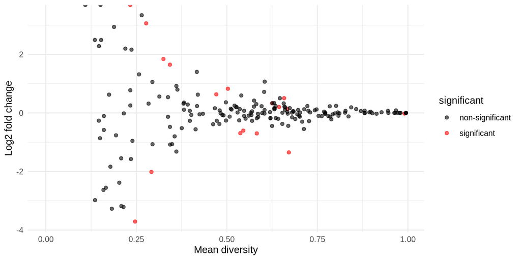

```r
# MA plot using helper
p_ma <- plot_ma(res)
print(p_ma)
```

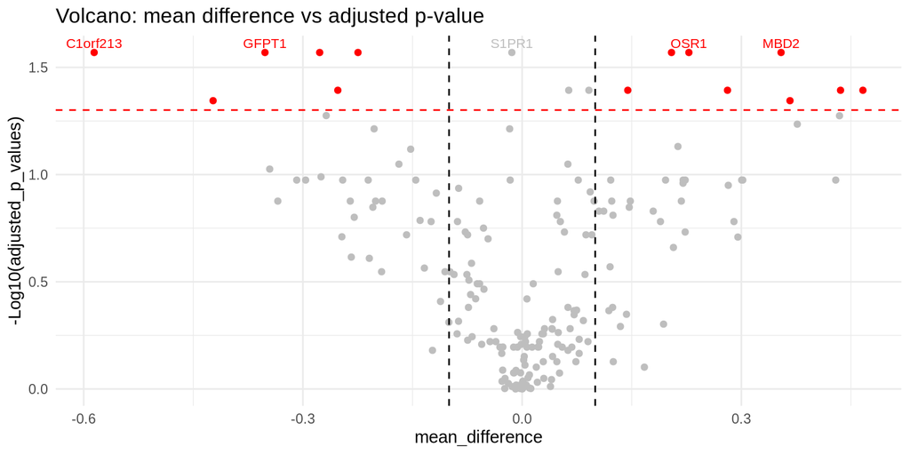

```r
# Volcano plot: mean difference vs -log10(adjusted p-value)
if (all(c("mean_difference", "adjusted_p_values") %in% colnames(res))) {
  res$label <- apply(res[, c("mean_difference", "adjusted_p_values")], 1,
                     function(x) ifelse(abs(as.numeric(x[1])) >= 0.1 & as.numeric(x[2]) < 0.05,
                                        "significant", "non-significant"))
  p_volcano <- plot_volcano(res)
  print(p_volcano)
}
```

## Plot all transcripts for the top 3 genes from the single-q differential analysis

Here we visualize transcript-level expression for the most significant genes identified in the previous step. The `plot_top_transcripts()` helper expects transcript-level counts (rows = transcripts) with rownames matching the `tx2gene` mapping. We plot the top three genes by significance to inspect isoform-level patterns that may explain the diversity differences.

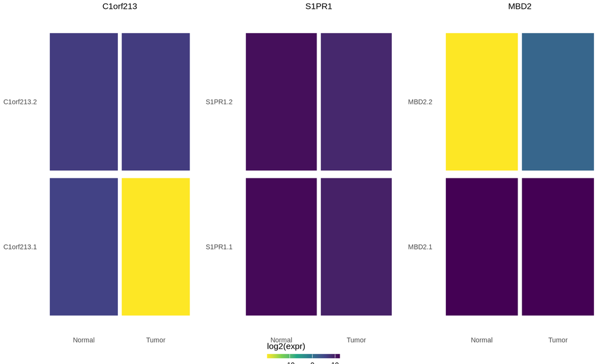

```r
if (is.data.frame(res) && nrow(res) > 0) {
  # select significant genes (adj p < 0.05 when available) and take top 3 by significance
  if ("adjusted_p_values" %in% colnames(res)) {
    sig_res <- res[res$adjusted_p_values < 0.05, , drop = FALSE]
  } else if ("p_values" %in% colnames(res)) {
    sig_res <- res[res$p_values < 0.05, , drop = FALSE]
  } else {
    sig_res <- res
  }
  if (nrow(sig_res) == 0) {
    message("No significant genes found; falling back to top genes by p-value.")
    top_genes <- head(res$genes, 3)
  } else {
    top_genes <- head(as.character(sig_res$genes), 3)
  }
  # prepare sample grouping vector (from earlier in vignette)
  sample_base_names <- sub("_q=.*", "", colnames(assay(ts_se)))
  samples_vec <- if (exists("coldata_df") && !is.null(coldata_df) && "sample_type" %in% colnames(SummarizedExperiment::colData(ts_se))) {
    as.character(SummarizedExperiment::colData(ts_se)$sample_type)
  } else {
    ifelse(grepl("_N$", sample_base_names), "Normal", "Tumor")
  }
  counts_for_plot <- readcounts
  if (is.null(rownames(counts_for_plot))) {
    message("Skipping transcript plots: `readcounts` does not have transcript rownames.",
            " Provide transcript-level counts with rownames to use `plot_top_transcripts()`.")
  } else {
    p_comb <- plot_top_transcripts(counts_for_plot, gene = top_genes, samples = samples_vec, tx2gene = tx2gene_tsv, top_n = NULL)
    print(p_comb)
  }
}
```

Inspect transcript-level counts for the top genes to understand isoform patterns that may drive diversity differences.

# Compare between q values

Compute normalized Tsallis entropy for two `q` values (0.1 and 2) to compare scale-dependent behavior.

```r
# compute Tsallis entropy for q = 1 (normalized)
q <- c(0.1, 2)
ts_se <- calculate_diversity(readcounts, genes, method = "tsallis", q = q, norm = TRUE)
head(assay(ts_se)[1:5,1:5])
```

```
#>         TCGA-A7-A0CH_N_q=0.1 TCGA-A7-A0CH_T_q=0.1 TCGA-A7-A0D9_N_q=0.1
#> MXRA8              0.8616275            0.6063802            0.6609111
#> C1orf86            0.0000000            0.0000000            0.0000000
#> PDPN               0.3486679            0.6619058            0.3395884
#> ALDH4A1            0.8111864            0.7478309            0.4667361
#> HNRNPR             0.5204909            0.6176153            0.6683829
#>         TCGA-A7-A0D9_T_q=0.1 TCGA-A7-A0DB_T_q=0.1
#> MXRA8              0.3925463            0.8156972
#> C1orf86            0.0000000            0.0000000
#> PDPN               0.5044987            0.0000000
#> ALDH4A1            0.2841620            0.8621495
#> HNRNPR             0.6856195            0.7395887
```

It allows to compare values across `q` for the same gene to see whether diversity differences are scale-dependent (e.g., significant at `q=0.1` but not at `q=2` suggests rare-isoform-driven changes).

Map optional sample metadata into the multi-q `SummarizedExperiment` so plotting helpers have access to `sample_type` for grouping.

```r
# If we read an external coldata table, map its Condition values to the
# SummarizedExperiment so plotting and downstream functions can use it.
if (!is.null(coldata_df)) {
  sample_base_names <- sub("_q=.*", "", colnames(SummarizedExperiment::assay(ts_se)))
  st_map <- setNames(coldata_df$Condition, coldata_df$Sample)
  sample_types <- unname(st_map[sample_base_names])
  missing_idx <- which(is.na(sample_types))
  if (length(missing_idx) > 0) {
    sample_types[missing_idx] <- infer_sample_group(sample_base_names[missing_idx])
  }
  SummarizedExperiment::colData(ts_se)$sample_type <- sample_types
}
```

Create violin and density plots summarizing diversity across multiple `q` values to show distributional differences between groups.

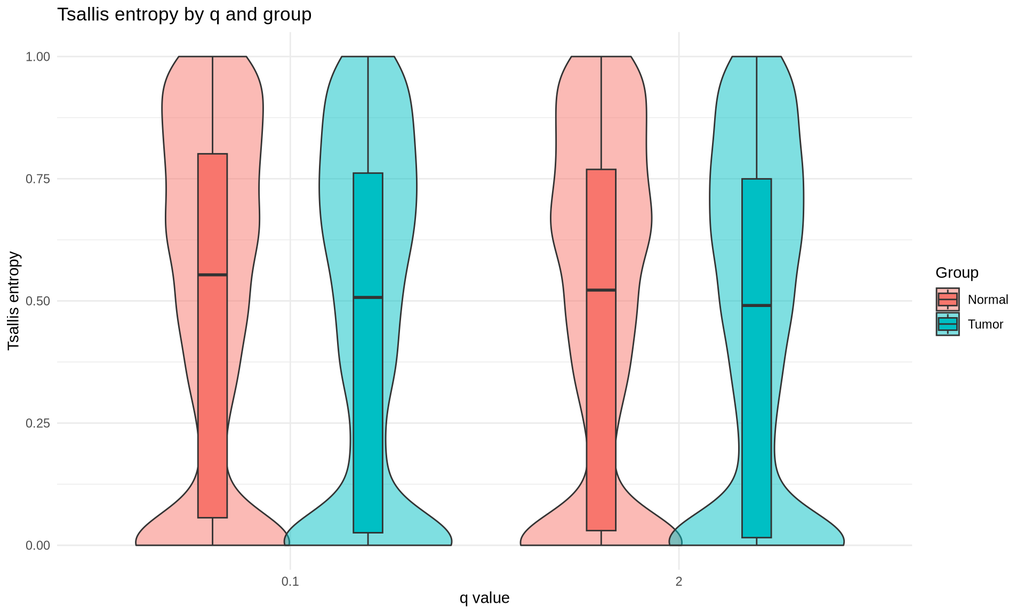

```r
## Use package plot helpers for multi-q violin and density
p_violin <- plot_tsallis_violin_multq(ts_se, assay_name = "diversity")
print(p_violin)
```

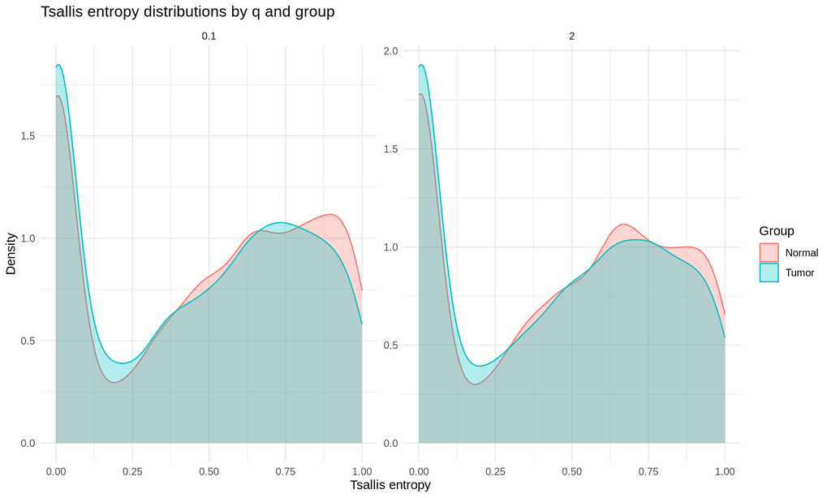

```r
p_density <- plot_tsallis_density_multq(ts_se, assay_name = "diversity")
print(p_density)
```

# Linear-model interaction across q values

Use the per-gene linear-model interaction test implemented in `calculate_lm_interaction()` to test whether the relationship between Tsallis entropy and q differs between groups.

This test fits a simple linear model per gene to assess whether the slope of the q-curve differs between sample groups. It can help identify genes whose response to the entropy scale parameter `q` is group-specific, indicating changes in isoform-dominance dynamics rather than only an overall shift in diversity.

```r
# compute Tsallis entropy for a sequence of values (normalized)
qvec <- seq(0.01, 2, by = 0.1)
ts_se <- calculate_diversity(readcounts, genes, method = "tsallis", q = qvec, norm = TRUE)
head(assay(ts_se)[1:5,1:5])
```

```
#>         TCGA-A7-A0CH_N_q=0.01 TCGA-A7-A0CH_T_q=0.01 TCGA-A7-A0D9_N_q=0.01
#> MXRA8               0.9840684             0.8500785             0.7527194
#> C1orf86             0.0000000             0.0000000             0.0000000
#> PDPN                0.3348515             0.3502196             0.3659083
#> ALDH4A1             0.9759153             0.7976183             0.6982381
#> HNRNPR              0.5653272             0.5164881             0.4849368
#>         TCGA-A7-A0D9_T_q=0.01 TCGA-A7-A0DB_T_q=0.01
#> MXRA8               0.6818220             0.6303117
#> C1orf86             0.0000000             0.0000000
#> PDPN                0.3818895             0.3981326
#> ALDH4A1             0.6447807             0.6181672
#> HNRNPR              0.4655343             0.4548022
```

The q-sequence produces a q-curve per sample and gene. These curves show how diversity emphasis shifts from rare to dominant isoforms as `q` increases and form the basis for interaction tests.

Map the sample metadata into the multi-q `SummarizedExperiment` as before.

```r
# If we read an external coldata table, map its Condition values to the
# SummarizedExperiment so plotting and downstream functions can use it.
if (!is.null(coldata_df)) {
  sample_base_names <- sub("_q=.*", "", colnames(SummarizedExperiment::assay(ts_se)))
  st_map <- setNames(coldata_df$Condition, coldata_df$Sample)
  sample_types <- unname(st_map[sample_base_names])
  missing_idx <- which(is.na(sample_types))
  if (length(missing_idx) > 0) {
    sample_types[missing_idx] <- infer_sample_group(sample_base_names[missing_idx])
  }
  SummarizedExperiment::colData(ts_se)$sample_type <- sample_types
}
```

```r
# ensure the SummarizedExperiment contains sample names with group suffixes
# (the function infers group from sample name suffix _N -> Normal)
lm_res <- calculate_lm_interaction(ts_se, sample_type_col = "sample_type", min_obs = 8)
```

```
#> [calculate_lm_interaction] method=linear
#> [calculate_lm_interaction] parsed samples and groups; starting per-gene fits
```

```r
head(lm_res)
```

```
#>      gene p_interaction adj_p_interaction
#> 1 PPP2R1A     0.7454960         0.9997906
#> 2    MDH1     0.7721388         0.9997906
#> 3    ZZZ3     0.7844040         0.9997906
#> 4   ACACB     0.7869660         0.9997906
#> 5  CAPZA2     0.7916957         0.9997906
#> 6  EFTUD2     0.7948379         0.9997906
```

Run a per-gene linear-model interaction test to find genes whose q-curve response differs between sample groups.

## Interaction test examples (toy dataset + TCGA full-run)

The short examples below demonstrate (1) toy examples that execute quickly inside the vignette and (2) templates for running the interaction tests on the full `tcga_brca_luma_dataset`. Full TCGA runs are computationally heavy and are therefore provided with `eval=FALSE` so readers can run them locally when desired.

### Tiny toy examples (fast)

```r
# Toy transcript-level counts for a single gene with 3 transcripts and 2 samples
txmat <- matrix(c(10, 1, 0,  2, 2, 2), nrow = 3, ncol = 2)
rownames(txmat) <- paste0("tx", 1:3)
colnames(txmat) <- c("SampleA", "SampleB")
genes_map <- rep("GeneX", nrow(txmat))

# Compute Hill numbers (D_q) for q = 0.5, 1, 2 (what = "D" returns Hill numbers)
se_hill <- calculate_diversity(txmat, genes = genes_map, q = c(0.5, 1, 2), what = "D")
SummarizedExperiment::assay(se_hill)
```

```
#>       SampleA_q=0.5 SampleB_q=0.5 SampleA_q=1 SampleB_q=1 SampleA_q=2
#> GeneX       1.57496      1.356131     1.19802           3           3
#>       SampleB_q=2
#> GeneX           3
```

```r
# Build a tiny diversity assay with two groups (A, B) and three q values each
mat <- matrix(runif(12, 0.2, 1.5), nrow = 2)
rownames(mat) <- c("Gene1", "Gene2")
colnames(mat) <- c("A_q=0.5", "A_q=1", "A_q=2", "B_q=0.5", "B_q=1", "B_q=2")

coldata <- S4Vectors::DataFrame(
  samples = colnames(mat),
  group = rep(c("Normal", "Tumor"), each = 3),
  row.names = colnames(mat)
)

se_small <- SummarizedExperiment::SummarizedExperiment(assays = list(diversity = mat), colData = coldata)

# FPCA (toy)
print(calculate_lm_interaction(se_small, sample_type_col = "group", method = "fpca", min_obs = 2))
```

```
#> [calculate_lm_interaction] method=fpca
#> [calculate_lm_interaction] parsed samples and groups; starting per-gene fits
#> data frame with 0 columns and 0 rows
```

```r
if (requireNamespace("mgcv", quietly = TRUE)) {
  # GAM (toy)
  print(calculate_lm_interaction(se_small, sample_type_col = "group", method = "gam", min_obs = 2))
} else {
  message("Package 'mgcv' not available; skipping toy GAM interaction demo.")
}
```

```
#> [calculate_lm_interaction] method=gam
#> [calculate_lm_interaction] parsed samples and groups; starting per-gene fits
#> data frame with 0 columns and 0 rows
```

### Full TCGA examples (templates — `eval=FALSE`)

The commands below show how to run the FPCA and GAM interaction tests on the full `tcga_brca_luma_dataset`. These are left `eval=FALSE` in the vignette to avoid long runtimes during automatic builds; remove `eval=FALSE` to execute locally when you have sufficient resources.

```r
# Load the package and dataset
library(abyssEdge)
data(tcga_brca_luma_dataset)
genes <- tcga_brca_luma_dataset[,1]
counts <- as.matrix(tcga_brca_luma_dataset[,-1])

# compute multi-q diversity (choose q grid you want)
qvals <- c(0.5, 0.75, 1, 1.25, 1.5)
se_div <- calculate_diversity(counts, genes = genes, q = qvals, what = "S", norm = TRUE)

# attach coldata (from inst/extdata/coldata.tsv shipped with package)
coldata <- read.table(system.file("extdata","coldata.tsv", package = "abyssEdge"), header = TRUE, sep = "\t")
st_map <- setNames(coldata$Condition, coldata$Sample)
sample_base_names <- sub("_q=.*", "", colnames(SummarizedExperiment::assay(se_div)))
SummarizedExperiment::colData(se_div)$sample_type <- unname(st_map[sample_base_names])

# run FPCA interaction test (may take several minutes)
fpca_res <- calculate_lm_interaction(se_div, sample_type_col = "sample_type", method = "fpca", min_obs = 5)
head(fpca_res)
```

```r
# run GAM interaction test on full TCGA dataset (may take considerably longer)
# ensure mgcv is installed
if (!requireNamespace("mgcv", quietly = TRUE)) install.packages("mgcv")
gam_res <- calculate_lm_interaction(se_div, sample_type_col = "sample_type", method = "gam", min_obs = 5)
head(gam_res)
```

Note: the TCGA templates above are provided for reproducibility; the vignette uses tiny toy examples for quick illustration and leaves the full-data runs to users with compute resources.

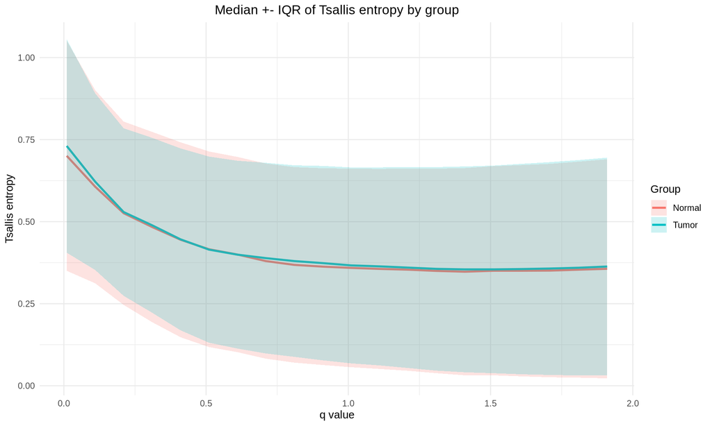

```r
# q-curve: median ± IQR across q values by group
p3 <- plot_tsallis_q_curve(readcounts, genes, q_values = qvec)
print(p3)
```

The q-curve shows entropy as a function of `q`. Diverging curves between groups indicate scale-dependent diversity differences. Separation at low `q` implies differences in rare isoforms; separation at high `q` signals differences in dominant isoforms.

Plot the Tsallis q-curve (entropy vs q) to visualize how diversity changes with `q` across sample groups.

## References

- Tsallis C. (1988). Possible generalization of Boltzmann–Gibbs statistics. Journal of Statistical Physics, 52:479–487.
- Tsallis C. (2009). Introduction to Nonextensive Statistical Mechanics: Approaching a Complex World. Springer.
- Rényi A. (1961). On measures of entropy and information. In Proceedings of the Fourth Berkeley Symposium on Mathematical Statistics and Probability, Vol. 1.
- Langton C.G. (1990). Computation at the edge of chaos: phase transitions and emergent computation. Physica D.
- Hill M.O. (1973). Diversity and evenness: a unifying notation and its consequences. Ecology, 54(2):427–432.
- Jost L. (2006). Entropy and diversity. Oikos, 113(2):363–375.
- Chao A. & Shen T.-J. (2003). Nonparametric estimation of Shannon’s index of diversity when there are unseen species. Environmental and Ecological Statistics, 10:429–443.
- Chao A., Chiu C.-H., & Jost L. (2014). Unifying species diversity, phylogenetic diversity, functional diversity, and related similarity measures through Hill numbers. Annual Review of Ecology, Evolution, and Systematics, 45:297–324.
- Aitchison J. (1986). The Statistical Analysis of Compositional Data. Chapman & Hall.